# Spectral Correction

Consider some spectra. Let’s use roGFP1:

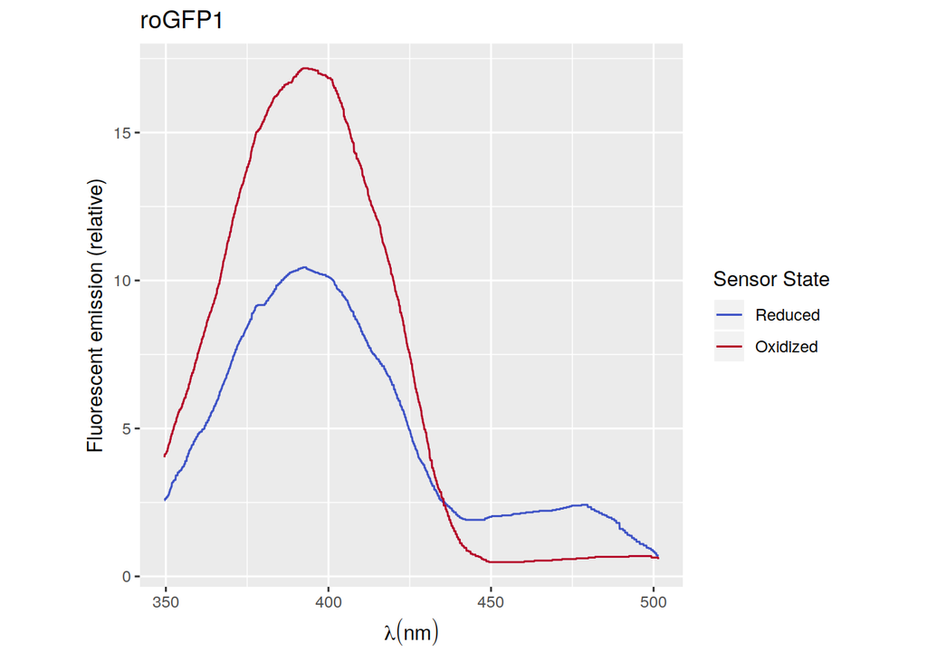

```r
roGFP1_data <- read.csv("../Raw_Spectra/rogfp1.csv", header = TRUE)
roGFP1_spectra <- spectraMatrixFromValues(
    lambdas_minimum = roGFP1_data$Lambda_Reduced,
    values_minimum = roGFP1_data$Values_Reduced,
    lambdas_maximum = roGFP1_data$Lambda_Oxidized,
    values_maximum = roGFP1_data$Values_Oxidized)
gfp1_spectraPlot <- plotSpectra(roGFP1_spectra, "Reduced", "Oxidized") + ggtitle("roGFP1")
gfp1_spectraPlot +
  theme(aspect.ratio=1)
```

Let’s say when that sensor is oxidized, it is actually 95% oxidized. Similarly, when the sensor is reduced, it’s actually only 90% reduced. This is an extreme case for the sake of having nice(r) numbers

We can describe the *95% oxidized* curve’s intensity as a function of the **limiting** oxidized curve’s intensity and and the **limiting** reduced curve’s intensity.

First, let’s look at JUST the intensity at $400nm$. We’ll then expand to any wavelength.

$$I_{400} = I_X * P_{X} + I_R * P_{R}$$

Where $I_{400}$ is the intensity at $400nm$, $I_X$ and $I_R$ are the intensity of the limiting oxidized and reduced curves, respectively, and $P_X$ and $P_R$ are the preportions of the oxidized and reduced curves that $I_{400}$ comes from.

We have two unknowns in that equation: $I_X$ and $I_R$. To solve for two unknowns, we’ll need two equations. That’s why we’ll need to use intensity values from two non-limiting curves–e.g. the 95% oxidized and 90% reduced curves in this example.

Let’s fill in some blanks. What’s the intensity at $400nm$ of our two curves?

```r
# Oxidized curve intensity at 400
roGFP1_spectra@values_maximum[abs(roGFP1_spectra@lambdas - 400) < 0.05]
```

```
## [1] 16.84076
```

```r
# Reduced curve intensity at 400
roGFP1_spectra@values_minimum[abs(roGFP1_spectra@lambdas - 400) < 0.05]
```

```
## [1] 10.11465
```

So our intensities are $16.84$ for our 95% oxidized curve and $10.11$ for our 90% reduced curve. We can now make a system of equations:

$$16.84 = I_X * 0.95 + I_R * 0.05$$
and
$$10.11 = I_X * 0.10 + I_R * 0.90$$

We can describe this as an augmented matrix:

$$\left[\begin{array}{rr|r}
0.95 & 0.05 & 16.84 \\
0.10 & 0.90 & 10.11
\end{array}\right]$$

And R is nice enough to be able to solve matricies for us

```r
solve(matrix(c(0.95, 0.10, 0.05, 0.90), nrow = 2), c(16.84, 10.11))
```

```
## [1] 17.235882  9.318235
```

So our values were $16.84$ and $10.11$ but they should have been $17.24$ and $9.32$.

Cool, so we can apply this general principle for all of the intensity values in our spectra.

First, we get the intensity values across all lambdas (I’ll just show a few)

```r
# Oxidized curve intensity
head(roGFP1_spectra@values_maximum)
```

```
## [1] 4.025478 4.127389 4.127389 4.127389 4.152866 4.152866
```

```r
# Reduced curve intensity 0
head(roGFP1_spectra@values_minimum)
```

```
## [1] 2.573248 2.573248 2.624204 2.624204 2.624204 2.624204
```

We can generally say:

$$I_1 = I_X * 0.95 + I_R * 0.05$$
and
$$I_2 = I_X * 0.10 + I_R * 0.90$$

For all intensity values $I$ from the 1st (95% oxidized) and 2nd (90% reduced) curves.

That gives us a matrix for every intensity value, and we can solve all of those:

```r
new_maximum <- c()
new_minimum <- c()

interleaved_intensities <- c(rbind(roGFP1_spectra@values_maximum, roGFP1_spectra@values_minimum))

for ( index in seq(1,length(interleaved_intensities),2) ) {
    b <- interleaved_intensities[index:(index+1)]
    a <- matrix(c(0.95, 0.10, 0.05, 0.90), nrow = 2)
    answer <- solve(a, b)

    new_maximum <- c(new_maximum, answer[1])
    new_minimum <- c(new_minimum, answer[2])

}

head(new_maximum)
```

```
## [1] 4.110903 4.218809 4.215811 4.215811 4.242788 4.242788
```

```r
head(new_minimum)
```

```
## [1] 2.402398 2.390408 2.447359 2.447359 2.444361 2.444361
```

Plot of the adjusted spectra:

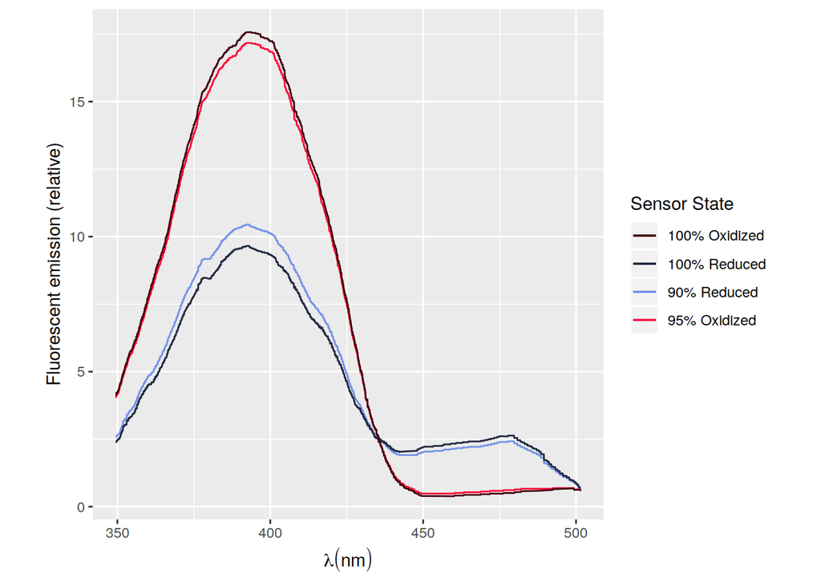

```r
roGFP1_adjSpectra <- new("sensorSpectra", lambdas = roGFP1_spectra@lambdas,
                         values_maximum = new_maximum,
                         values_minimum = new_minimum)

ggplot() +
    geom_line(aes(x = roGFP1_spectra@lambdas,
                  y = roGFP1_spectra@values_minimum, color = "90% Reduced")) +
    geom_line(aes(x = roGFP1_spectra@lambdas,
                  y = roGFP1_spectra@values_maximum, color = "95% Oxidized")) +
    geom_line(aes(x = roGFP1_adjSpectra@lambdas,
                  y = roGFP1_adjSpectra@values_minimum, color = "100% Reduced")) +
    geom_line(aes(x = roGFP1_adjSpectra@lambdas,
                  y = roGFP1_adjSpectra@values_maximum, color = "100% Oxidized")) +
    scale_color_manual(name = "Sensor State",
                       values = c("90% Reduced" ="#7291E8",
                                  "100% Reduced" ="#1F2840",
                                  "95% Oxidized" ="#FF0537",
                                  "100% Oxidized" ="#40010E")) +
    xlab(expression(lambda (nm)))  +
    ylab("Fluorescent emission (relative)") +
    theme(aspect.ratio=1)
```

And I can make a function that generalizes this method:

```r
fix_spectra <- function(curve_1, pmax_1, curve_2, pmax_2) {
    new_maximum <- c()
    new_minimum <- c()

interleaved_intensities <- c(rbind(curve1, curve2))

for ( index in seq(1,length(interleaved_intensities),2) ) {
    b <- interleaved_intensities[index:(index+1)]
    a <- matrix(c(pmax_1, 1-pmax_1, pmax_2, 1-pmax_2), nrow = 2)
    answer <- solve(a, b)

    new_maximum <- c(new_maximum, answer[1])
    new_minimum <- c(new_minimum, answer[2])

}

return(data.frame(new_maximum = new_maximum, new_minimum = new_minimum))

}
```